# Análise de taxa de sucesso de filmes

Para todas as análises apresentadas usaremos, primordialmente, dois indicadores: a nota média (nota_media) e o lucro médio (lucro_medio). A nota média é a média simples das avaliações do IMDB dos filmes. O lucro médio é a média do lucro dos filmes, sendo o lucro a diferença entre receita e orçamento.

Para cada quesito a ser decidido para a produção de um filme, temos um bloco de análises comentadas e indicações.

## Indicação de um diretor

O diretor é parte fundamental da criação de um filme. É dele a responsabilidade de determinar qual visão será executada e garantir que todas as partes envolvidas trabalhem para trazê-la a vida.

Um diretor pode consagrar ou destruir uma grande ideia, tanto junto à crítica quanto ao público.

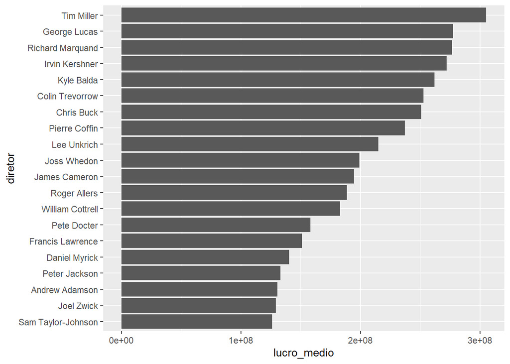

Lucro médio por diretor

```r
diretor_lucro
```

Para o gráfico foram considerados apenas os 20 diretores com os maiores lucros médios. O diretor **Tim Miller** é o responsável pelo melhor lucro médio, tendo boa vantagem sobre o segundo colocado **George Lucas**.

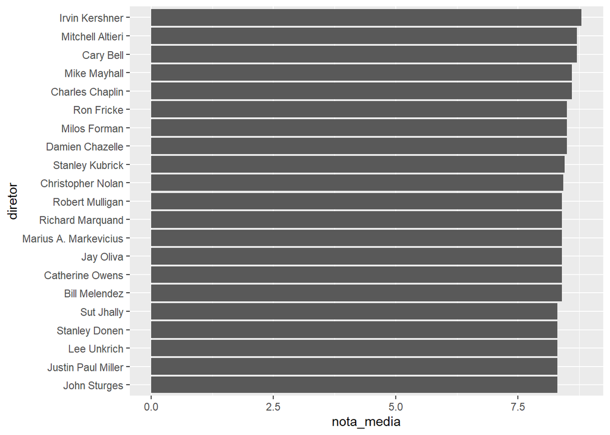

Nota média por diretor

```r
diretor_nota
```

Para o gráfico, foram considerados apenas os 20 diretores com as maiores avaliações médias. Nesse critério as diferenças entre os diretores são muito menores do que no critério lucro médio.

Considerando os dois gráficos, o melhor diretor para maximizar tanto o lucro quanto a avaliação parece ser **Irvin Kershner** - melhor nota média e quarto melhor lucro médio. No entanto é difícil recomendá-lo dada a desvantagem de ele ter falecido em 2010.

Como a posição relativa de outros diretores nos rankings de lucro e avaliação deixa margem para interpretação, precisamos de um **critério unificado** entre as duas grandezas para poder eleger um diretor. O critério que utilizaremos doravante foi chamado de nota e lucro relativos (nota_lucro_rel). Ele é calculado multiplicando o lucro de cada filme por sua nota. Em seguida esses valores são relativizados, dividindo todos pelo maior entre eles. Assim, o maior valor que nota_lucro_rel pode assumir é 1,0.

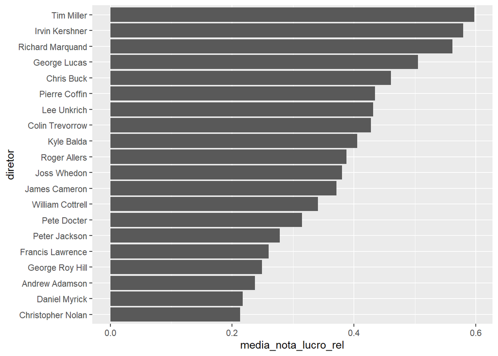

Relação lucro e avaliação por diretor

```r
diretor_rel_nota_lucro
```

Pelo novo critério, o diretor mais indicado para maximizar tanto o retorno financeiro quanto a avaliação do filme é **Tim Miller**.

O genero de um filme é fundamental para sua popularidade.

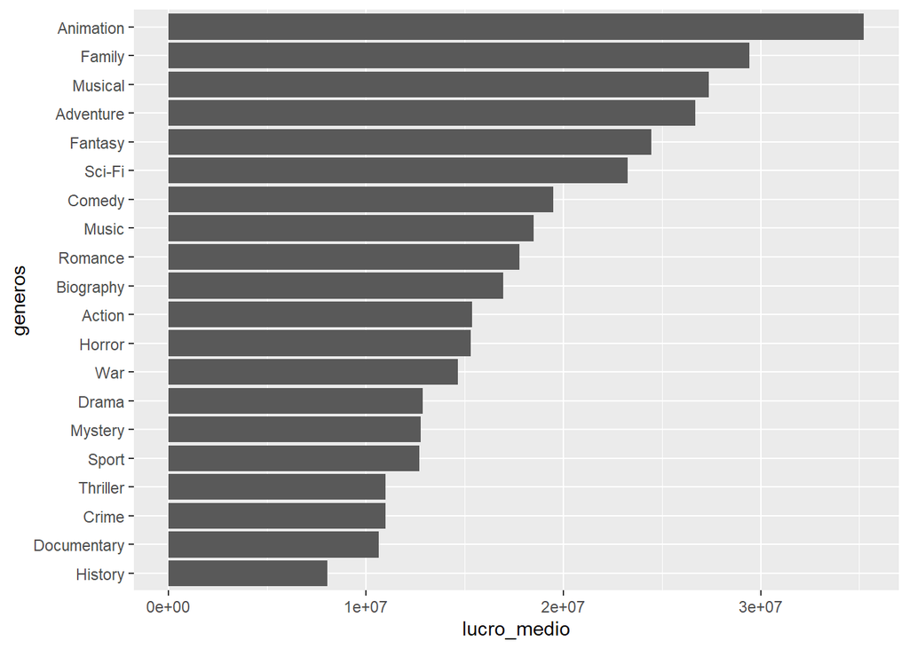

Lucro médio por gênero

```r
genero_lucro
```

O gênero mais lucrativo é o de **animações**, seguido por filmes **familiares** e **musicais**.

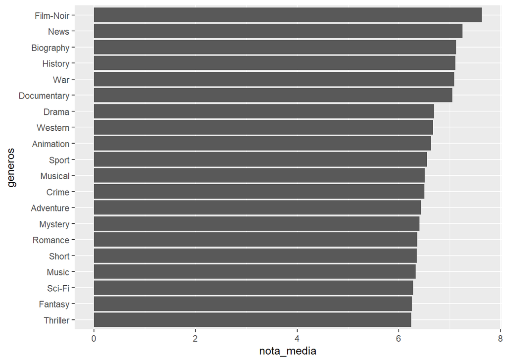

Nota média por gênero

```r
genero_nota
```

Os generos mais bem avaliados são os **filmes noir**, seguidos pelossobre **notícias** e **biográficos**. Fica claro que diferentes gêneros apelam de maneita diferente ao público e aos críticos.

Seguimos assim para o critério combinado.

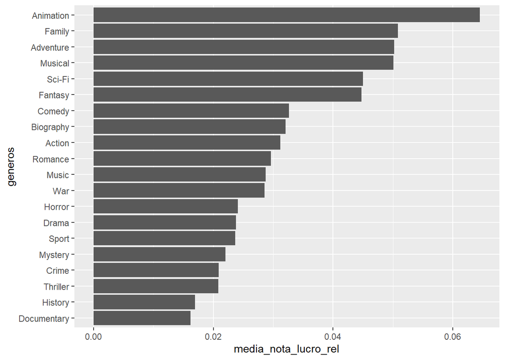

Relação lucro e avaliação por gênero

```r
genero_rel_nota_lucro
```

Pelo critério combinado, o gênero mais indicado para maximizar tanto o lucro e a avaliação é **animação**.

O elenco de um filme é certamente seu elemento de maior destaque. Bons atores são necessários para trazer a visão do diretor e dos roteiristas para a telona. Atores populares podem trazer milhares de seus fãs para as salas de cinema, e atores competentes podem elevar um filme bom ao status de clássico ao entregar performances memoráveis.

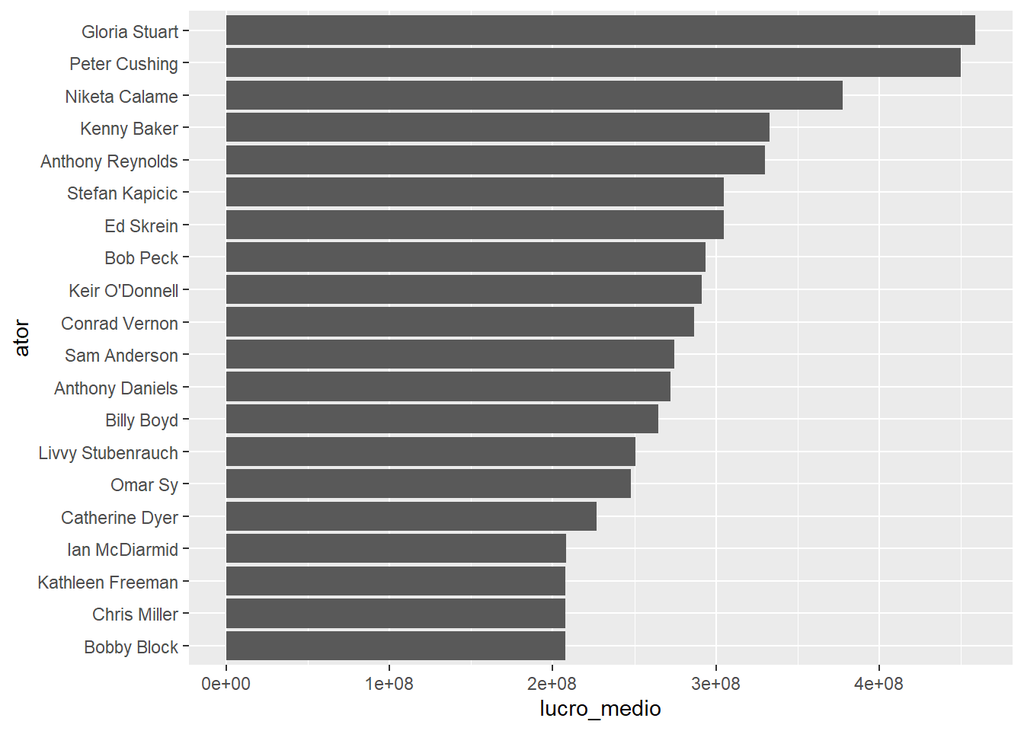

Lucro médio por ator principal

```r
ator_lucro
```

Os atores com as maiores bilheterias são **Gloria Stuart** e **Peter Cushing** que, infelizmente, foram no mesmo caminho de **Irvin Keshner** e estão permanentemente indisponíveis.

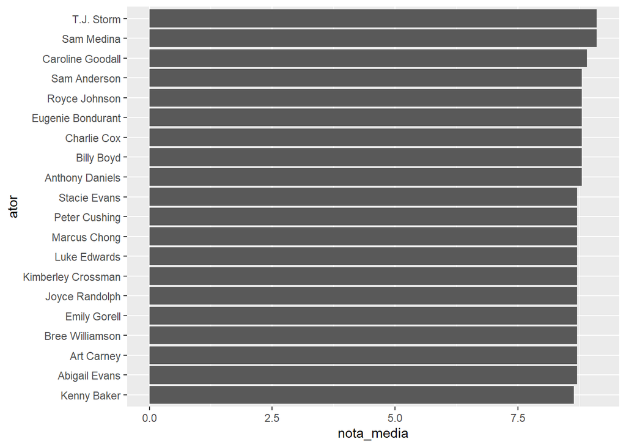

Nota média por ator

```r
ator_nota
```

Os atores com os filmes mais bem avaliados são **T. J. Storm**, **Sam Medina** e **Caroline Goodall**.

Como ocorreu anteriormente, um critério unificado se faz necessário.

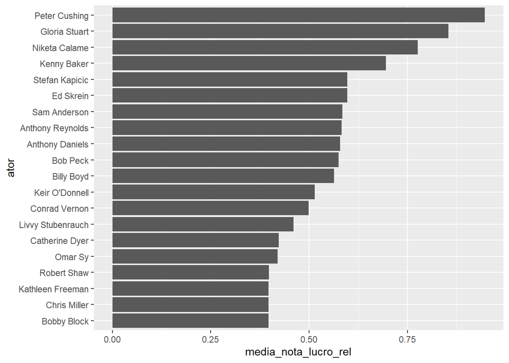

Relação lucro e avalização por ator

```r
ator_rel_nota_lucro
```